# Demo kort

Author

Martine Jansen

# Inleiding

Dit is een korte demonstratie van het gebruik van het `wisselstroom` package.

Dit document geeft een korte analyse gericht op wisselstroom, van het voorlopige bekostigingsbestand van 99XX, standdatum 2024-01-15.  
Het bestand bevat 181 inschrijvingsregels en 33 diplomaregels van 104 studenten die in ieder geval in een van de twee beschreven academische jaren (2022/2023 en 2023/2024 ) een inschrijving of een diploma hadden bij 99XX.

# Verdeling over de BRINS

Studenten kunnen in beide jaren bij 99XX ingeschreven staan, of in 1 van de twee. Daarnaast kunnen ze ook inschrijvingen hebben bij andere BRINs of niet in het hoger onderwijs ingeschreven zijn.  
Een overzicht in tabelvorm:

| situation_brin_2022/2023 | situation_brin_2023/2024 | n_students |
| --- | --- | --- |
| brin_own | brin_own | 49 |
| brin_own | other HE | 4 |
| brin_own | outside HE | 24 |
| brin_own & other HE | other HE | 1 |
| other HE | brin_own | 2 |
| outside HE | brin_own | 24 |

In een grafiek:

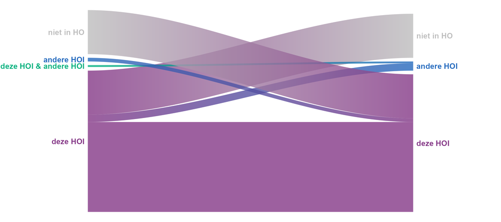

# Switch

Als een inschrijving eindigt zonder einddiploma, en de student begint het volgende academische jaar aan een andere opleiding, dan noemen we dat een switch.

Aantal switches van 2022/2023 naar 2023/2024 is te zien in de volgende tabel:

| from_brin | from_program | all_enrolments_otheryear | total_switch | with_prop | other |
| --- | --- | --- | --- | --- | --- |
| 73CC | 51021 | HBO-BA-99XX-31007 | 1 | 0 | 1 |
| 73CC | 51025 | HBO-BA-99XX-31009 | 1 | 0 | 1 |
| 74DD | 51025 | HBO-BA-99XX-31009 | 1 | 0 | 1 |
| 99XX | 31005 | HBO-BA-71AA-31005 | 1 | 0 | 1 |
| 99XX | 31006 | HBO-BA-99XX-31007 | 1 | 0 | 1 |
| 99XX | 31008 | HBO-BA-71AA-31024 | 1 | 0 | 1 |
| 99XX | 31008 | HBO-BA-99XX-31007 | 1 | 0 | 1 |
| 99XX | 31011 | HBO-BA-72BB-31010 | 1 | 0 | 1 |
| 99XX | 31018 | HBO-BA-99XX-31004 | 1 | 0 | 1 |

We kunnen ook alleen kijken naar switches van onze eigen instelling:

| from_brin | from_program | all_enrolments_otheryear | total_switch | with_prop | other |
| --- | --- | --- | --- | --- | --- |
| 99XX | 31005 | HBO-BA-71AA-31005 | 1 | 0 | 1 |
| 99XX | 31006 | HBO-BA-99XX-31007 | 1 | 0 | 1 |
| 99XX | 31008 | HBO-BA-71AA-31024 | 1 | 0 | 1 |
| 99XX | 31008 | HBO-BA-99XX-31007 | 1 | 0 | 1 |
| 99XX | 31011 | HBO-BA-72BB-31010 | 1 | 0 | 1 |
| 99XX | 31018 | HBO-BA-99XX-31004 | 1 | 0 | 1 |

# Na behalen diploma “31009”

Er zijn 3 studenten die in het academische jaar 2022/2023 het diploma hebben gehaald. Daarvan waren er 3 met hooguit 1 inschrijving brin/croho per jaar. Voor deze laatste groep staat in onderstaande tabel het vervolg aangegeven:

| brin_from | program_from | program_level_from | brin_to | program_to | program_level_to | n_students |
| --- | --- | --- | --- | --- | --- | --- |
| 99XX | 31009 | HBO-BA | NA | NA | NA | 2 |
| 99XX | 31009 | HBO-BA | 77GG | 61031 | WO-MA | 1 |